# Specific social coping behaviors and social supports that may impact suicidality

peter phalen

June 29 2019

Suicide researchers have long hypothesized that social factors are highly relevant to suicidality. There has been quite a bit of research into the exact way in which the stress associated with interpersonal relationships (e.g., thwarted belongingness, perceived burdnesomeness) can contribute to increased suicidality. However, there has been less research into the specific ways in which social coping might function to prevent against suicidality.

In this paper, we use the [Interpersonal Support Evaluation List](http://www.midss.org/sites/default/files/interpersonal_support_evaluation_list_and_scoring_isel.pdf) (ISEL) and the [COPE inventory](http://www.midss.org/sites/default/files/cope.pdf) to test for specific ways in which social relationships might buffer against suicidality in people who are at high risk.

```r
library(tidyverse)
library(rstanarm)
library(GGally)
library(corrplot)
library(bayesplot)
library(loo)
library(projpred)
library(knitr)
```

The sample consists of 50 male veterans diagnosed with depression.

```r
setwd("/Users/peterphalen/Downloads/JAHNDATA/")
dat <- read_csv("suicide_combined_all.csv")


# restrict to people with complete COPE data
dat <- dat[which(dat$cope_complete == 2),]
```

# 1.0 Preprocessing

We begin by calculating the relevant COPE and ISEL subscales:

```r
dat <- within(dat,
              {
                COPE.instrumental.social.support = cope_4 + cope_14 + cope_30 + cope_45
                COPE.emotional.social.support = cope_11 + cope_23 + cope_34 + cope_52
                ISEL.tangible = ISEL_TS
                ISEL.belonging = ISEL_BS
                ISEL.selfesteem = ISEL_SE
                ISEL.appraisal = ISEL_AS
                BSS_sum = as.integer(BSS_sum)
              })

# save subscale names as a vector so we don't have to keep retyping
social.subscales <-   c("COPE.instrumental.social.support",
                        "COPE.emotional.social.support",
                        'ISEL.tangible',
                        "ISEL.belonging",
                        "ISEL.selfesteem",
                        "ISEL.appraisal")
```

Create some basic demographic variables.

```r
dat <- within(dat,
       {
         marital <- factor(marital, levels=1:4, labels=c("married","widowed","divorced","single"))
         race <- factor(Race, levels=1:7, labels=c("AmerInd","AsianPI","AsianPI","Black","AsianPI","White","Multiple"))
         gender <- factor(male, 0:1, labels=c("female","male"))
       })
```

# 1.1 Descriptive statistics

Check distribution of demographic variables.

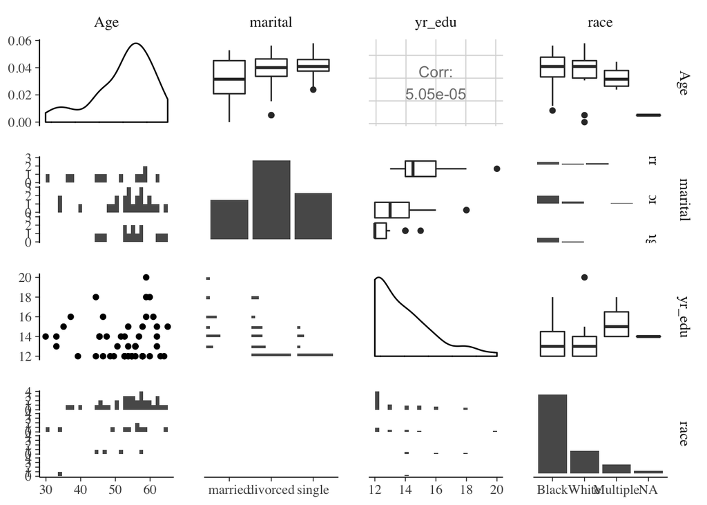

```r
demographic.vars <- c("Age",
                      "marital",
                      "yr_edu",
                      "race")

ggpairs(dat[demographic.vars])
```

Collapse people with unreported race (n=1) together with people who have multiple races (n=4).

```r
levels(dat$race)[which(levels(dat$race) == "Multiple")] <- "Other"
dat[is.na(dat$race),"race"] <- "Other"
summary(dat$race)
```

```
## AmerInd AsianPI   Black   White   Other
##       0       0      35      10       5
```

Create “AA” and “married” variable to make modeling easier

```r
table(dat$AA <- as.numeric(dat$race == "Black"))
```

```
##
##  0  1
## 15 35
```

```r
table(dat$married <- as.numeric(dat$marital == "married"))
```

```
##
##  0  1
## 38 12
```

Sample is all male so no point including this as a covariate:

```r
summary(dat$gender)
```

```
## female   male   NA's
##      0     49      1
```

Take a look at depression distribution, which we’ll also want to include in multivariate analyses.

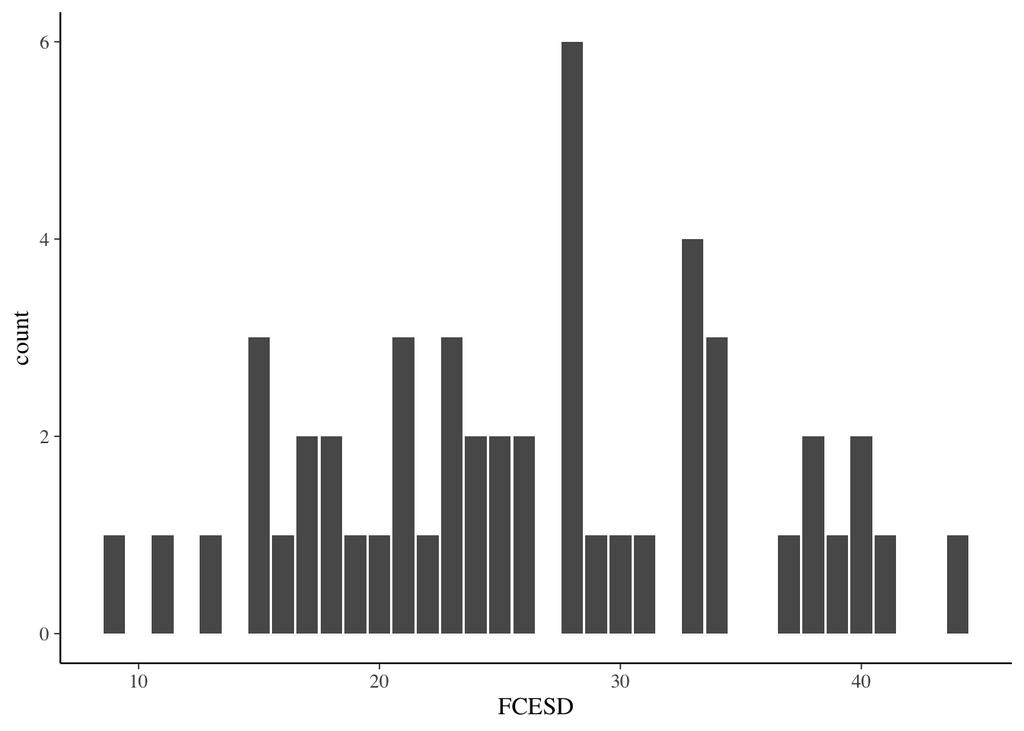

```r
ggplot(dat) +
  aes(x=FCESD) + # CESD depression
  geom_bar()
```

And anxiety…

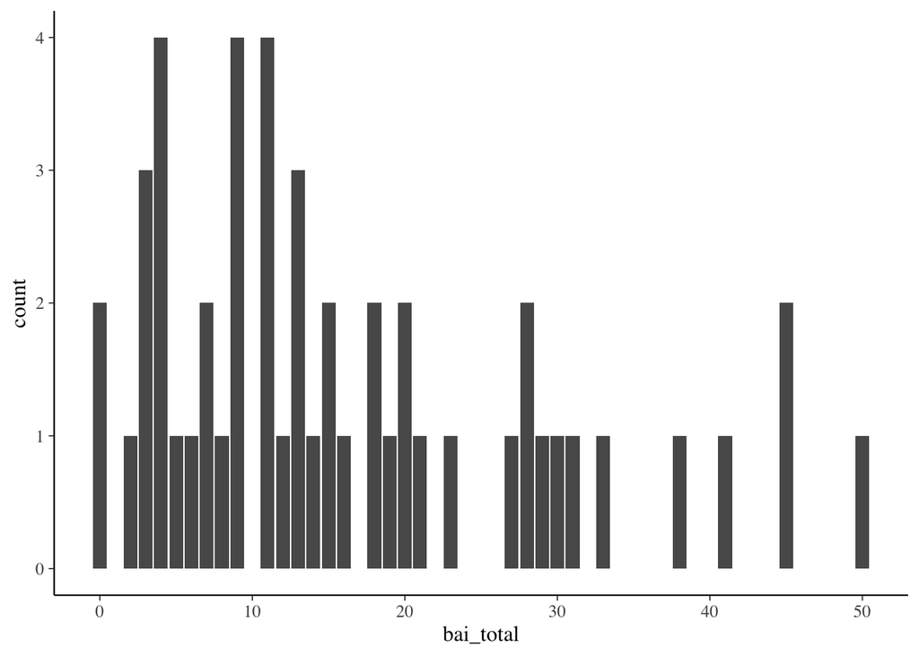

```r
ggplot(dat) +
  aes(x=bai_total) + # beck anxiety inventory
  geom_bar()
```

# 2.0 Suicide ideation and coping

Here’s the distribution of suicidal ideation in the sample, as measured by the Beck Scale for Suicide Ideation (BSS). About half the sample has some level of suicidal ideation.

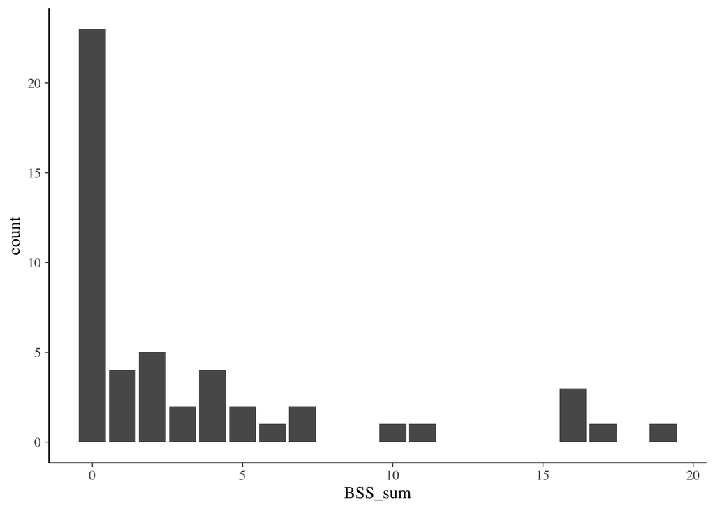

```r
ggplot(dat) +
  aes(x = BSS_sum) +
  geom_bar()
```

Log-transform of SSI probably makes the most sense–as confirmed by pairs plot farther down (relationships between BSS and subscales are log-linear).

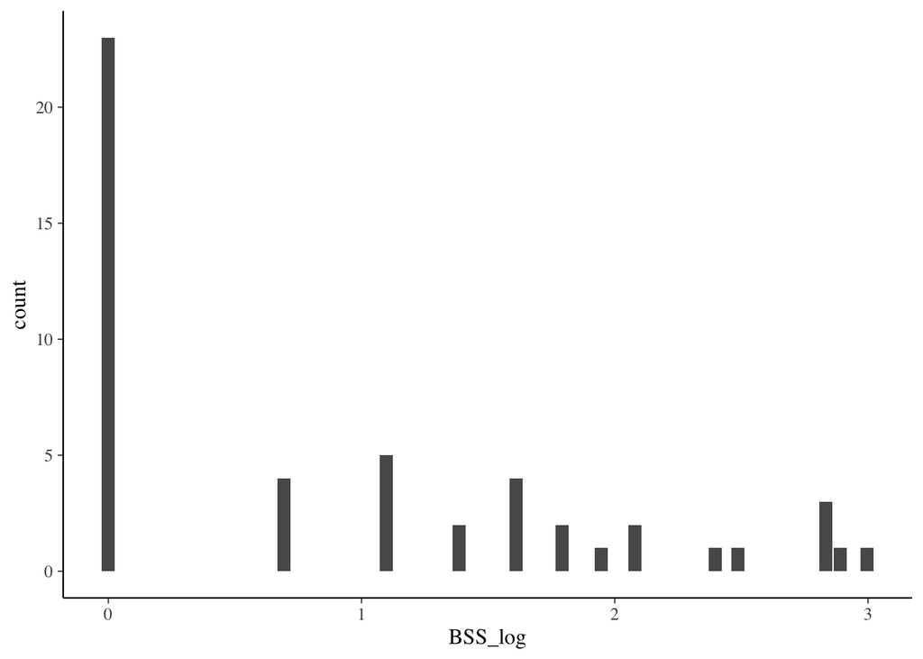

```r
dat$BSS_log <- log(dat$BSS_sum + 1)
ggplot(dat) +
  aes(x = BSS_log) +
  geom_bar()
```

## 2.1 Exploratory correlations

We first run correlations between all the COPE subscales and suicide ideation (`BSS_log`). Darker red indicates a more positive correlation. Darker blue indicates more negative. Nonsignificant correlations (p>.05) how have an X drawn over them. (But please remember that [filtering on statistical significance leads to overconfident expectations of replicability](https://arxiv.org/pdf/1702.00556.pdf).)

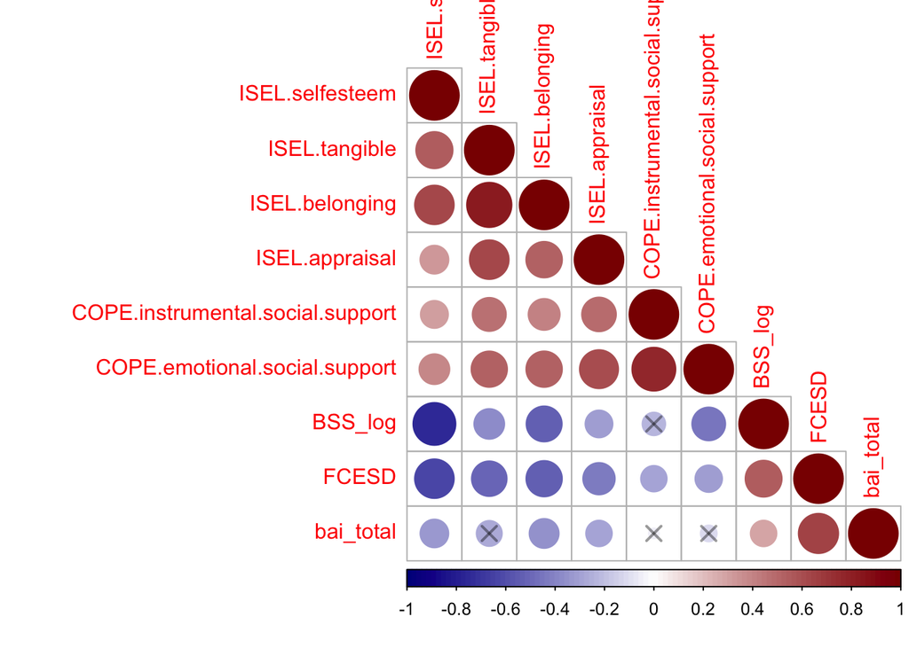

```r
# mat : is a matrix of data
# ... : further arguments to pass to the native R cor.test function
cor.mtest <- function(mat, ...) {
    mat <- as.matrix(mat)
    n <- ncol(mat)
    p.mat<- matrix(NA, n, n)
    diag(p.mat) <- 0
    for (i in 1:(n - 1)) {
        for (j in (i + 1):n) {
            tmp <- cor.test(mat[, i], mat[, j], ...)
            p.mat[i, j] <- p.mat[j, i] <- tmp$p.value
        }
    }
  colnames(p.mat) <- rownames(p.mat) <- colnames(mat)
  p.mat
}

M<-cor(dat[c(social.subscales,"BSS_log", "FCESD", "bai_total")], use = "pairwise.complete.obs")

# matrix of the p-value of the correlation
p.mat <- cor.mtest(dat[c(social.subscales,"BSS_log", "FCESD", "bai_total")])
corrplot(M, type="lower", order="hclust",
         col=colorRampPalette(c("darkblue", "white", "darkred"))(100),
         p.mat = p.mat, sig.level = 0.05,
         insig="pch", pch=4, pch.cex=1.5,
         pch.col=rgb(0,0,0,.4))
```

#### Check the most relevant variables

Look at relationship between SI and the statistically significant variables in some more detail.

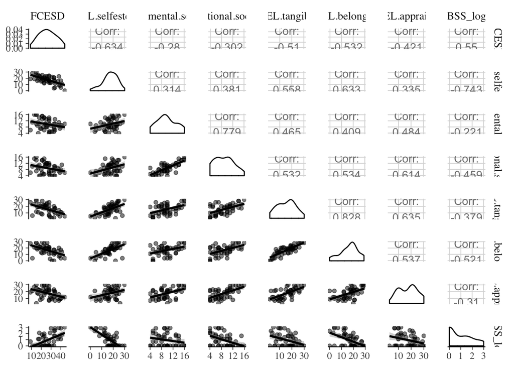

```r
ggpairs(subset(dat, select=c(FCESD,
                             ISEL.selfesteem,
                             COPE.instrumental.social.support,
                             COPE.emotional.social.support,
                             ISEL.tangible,
                             ISEL.belonging,
                             ISEL.appraisal,
                             BSS_log)),
        lower=list(continuous=wrap("smooth", col=rgb(0,0,0,alpha=.5))))
```

## 2.2 Multivariate analysis

Fit model, z-scoring continuous variables so that coefficients are easily comparable.

```r
# need to do this to avoid errors in projpred due to missing irrelevant variables
dat.sub <- subset(dat, select=c(married, AA, yr_edu, Age, FCESD, bai_total,
                                COPE.emotional.social.support, ISEL.tangible, ISEL.belonging,
                                ISEL.appraisal, ISEL.selfesteem, BSS_sum))
fit <- stan_glm(BSS_sum ~
                    scale(married) +
                    scale(AA) +
                   # z-score the continuous predictors to put them on a common scale
                    scale(yr_edu) +
                    scale(Age) +
                    scale(FCESD) +
                    scale(bai_total) +
                    scale(COPE.emotional.social.support) +
                    scale(ISEL.tangible) +
                    scale(ISEL.belonging) +
                    # scale(ISEL.selfesteem) +
                    scale(ISEL.appraisal)
                ,
                 iter=6000,
                 cores=4,
                QR=T,
                family=poisson,
                 data=dat.sub)
```

```r
r2 <- bayes_R2(fit)
median(r2)
```

```
## [1] 0.6539353
```

Plot parameter estimates with 95% credible intervals and 80% credible intervals shaded.

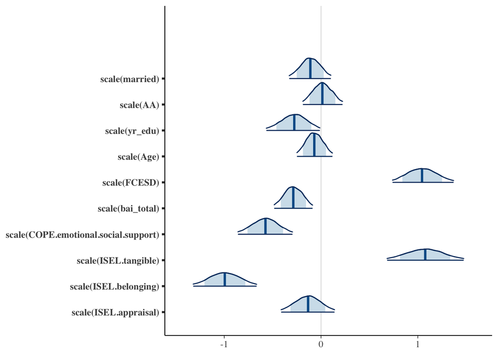

```r
plot(fit, "areas", pars="beta", prob_outer=.95, prob=.8)
```

It’s weird that ISEL-Tangible–a measure of instrumental social support (e.g. “If I were sick, I could easily find someone to help me with my daily chores”)–could predict *increased* suicidality. We might suspect that the problem is multicollinearity, as (e.g.) ISEL-Tangible and ISEL-Belonging are strongly correlated (see correlation matrix above). We can actually check this by analyzing the posterior samples.

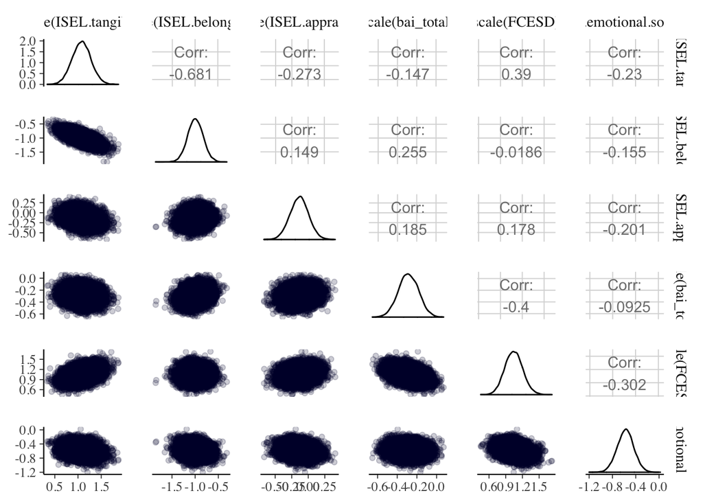

```r
ggpairs(as.data.frame(fit, regex_pars = c("ISEL.tangible", "ISEL.belonging", "ISEL.appraisal", "bai_total", "FCESD", "COPE.emotional.social.support")),
        lower=list(continuous=wrap("points", col=rgb(0,0,0.2,alpha=.2))))
```

We can see a fairly strong negative correlation between the coefficient estimates for ISEL-Tangible and the estimate for ISEL-Belonging, which means that attributing greater increases in suicidality to ISEL-Belonging requires attributing lesser increases to ISEL-Tangible.

Here’s a method of selecting variables in the context of multicollinearity using projective predictive variable selection (see https://avehtari.github.io/modelselection/collinear.html).

```r
fit_cv <- cv_varsel(fit, method="forward")
```

```
## [1] "Computing LOOs..."
##
## [1] "Performing the selection using all the data.."
## [1] "Done."
```

```r
vars <- names(fit_cv$vind)
kable(data.frame(rank = 1:length(fit_cv$vind), vars = vars))
```

| rank | vars |
| --- | --- |
| 1 | scale(FCESD) |
| 2 | scale(COPE.emotional.social.support) |
| 3 | scale(ISEL.belonging) |
| 4 | scale(ISEL.tangible) |
| 5 | scale(yr_edu) |
| 6 | scale(bai_total) |
| 7 | scale(married) |
| 8 | scale(ISEL.appraisal) |
| 9 | scale(Age) |
| 10 | scale(AA) |

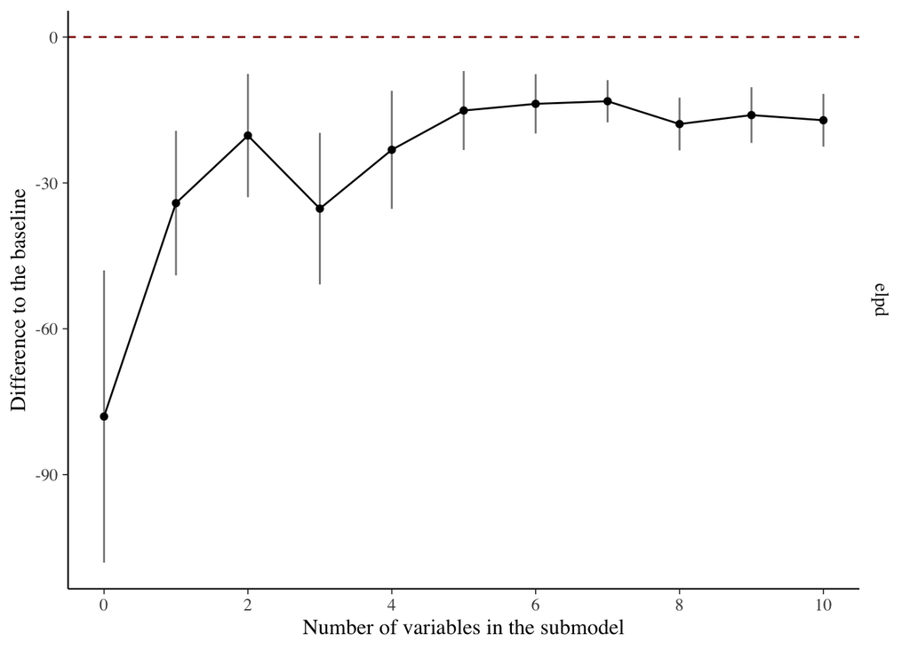

```r
varsel_plot(fit_cv, deltas=T)
```

Looks like the right number of variables may be 2 or 6, but the difference between 2 and 6 is negligible

```r
stats <- varsel_stats(fit_cv)
stats[which(stats$size==2),]
```

```
##                                      size vind      elpd  elpd.se pctch
## scale(COPE.emotional.social.support)    2    7 -157.5911 23.71815  0.94
```

```r
stats[which(stats$size==6),]
```

```
##                  size vind      elpd  elpd.se pctch
## scale(bai_total)    6    6 -151.0686 24.87326  0.96
```

```r
suggest_size(fit_cv, baseline="best")
```

```
## [1] 2
```

So we’ll stick with two variables…

```r
# we'll stick with two...
nv <- 2
# implied coefficient estimates for selected submodel
proj2 <- project(fit_cv, nv = nv, ns = 4000)
round(colMeans(as.matrix(proj2)),1)
```

```
##                          (Intercept)                         scale(FCESD)
##                                  0.6                                  0.8
## scale(COPE.emotional.social.support)
##                                 -0.7
```

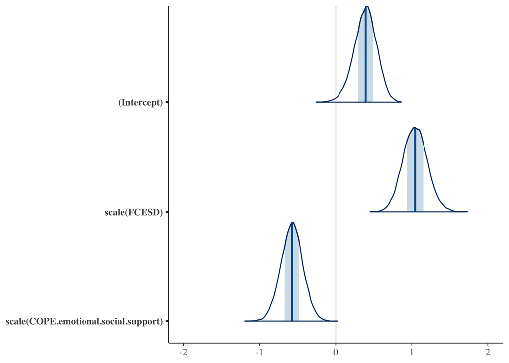

```r
# Visualise the three most relevant variables in the full model
mcmc_areas(as.matrix(fit),
           pars = c('(Intercept)', names(fit_cv$vind[1:nv]))) +
  coord_cartesian(xlim = c(-2, 2))
```

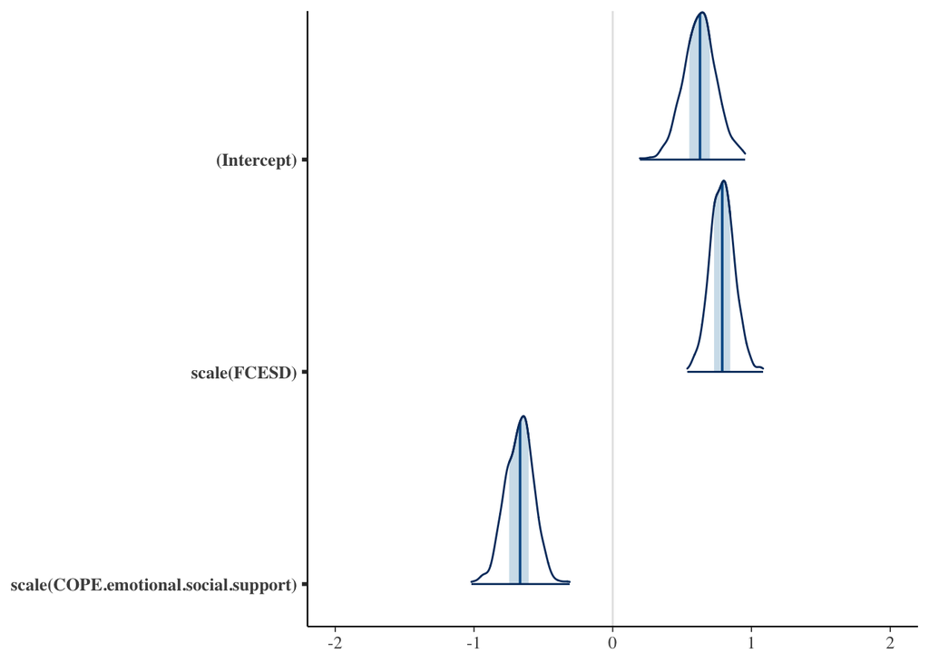

```r
# Visualise the projected three most relevant variables
proj <- project(fit_cv, nv = nv, ns = 500)
mcmc_areas(as.matrix(proj)) + coord_cartesian(xlim = c(-2, 2))
```

Refit model with variables selected from above.

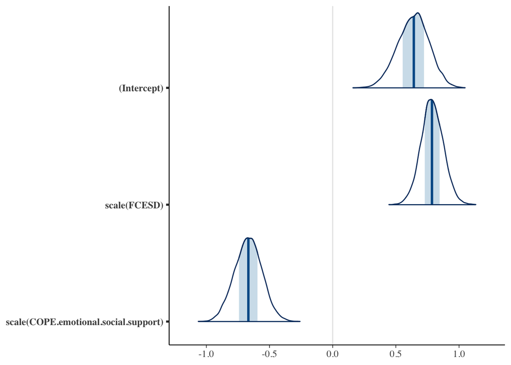

```r
fit2 <- stan_glm(BSS_sum ~
                   scale(FCESD) +
                   scale(COPE.emotional.social.support),
                 iter=6000,
                 adapt_delta=.999,
                 cores=4,
                family=poisson,
                 data=dat.sub)
plot(fit2,"areas")
```

## 2.3 Interpretation

Let’s think about what our model is saying.

#### FCESD

First depression. This one is straightforward.

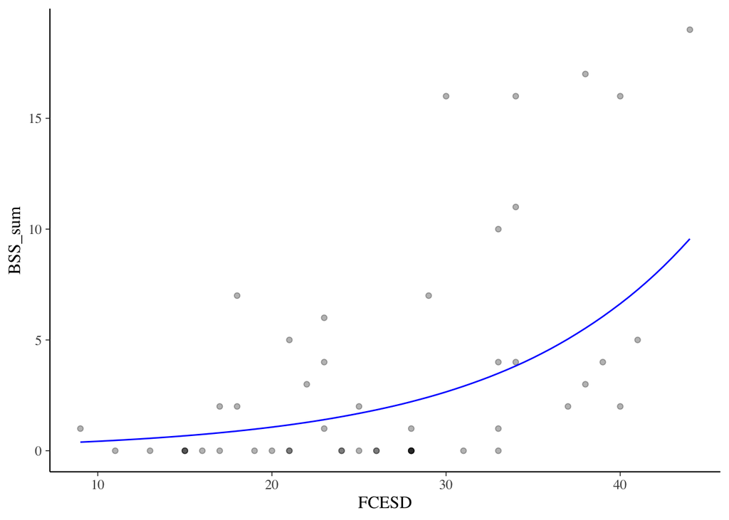

```r
range.FCESD <- range(dat$FCESD)
spread <- seq(range.FCESD[1], range.FCESD[2], by = .5)
newdata <- data.frame(
  FCESD = spread,
  COPE.emotional.social.support = mean(dat$COPE.emotional.social.support))
preds <- posterior_linpred(fit2, newdata=newdata, transform=TRUE)
preds <- apply(preds, 2, median)
preds <- data.frame( FCESD = spread,
            BSS_sum = preds)
ggplot(dat) +
  aes(y=BSS_sum,x=FCESD) +
  geom_point(alpha=.3) +
  geom_line(data=preds, col="blue")
```

#### COPE - Emotional Social Support

The emotional social support subscale consists of the following four items:

- I discuss my feelings with someone
- I try to get emotional support from friends or relatives
- I get sympathy and understanding from someone
- I talk to someone about how I feel

These are the specific kinds of coping strategies that may be associated with decreased suicidality even after controlling for depression.

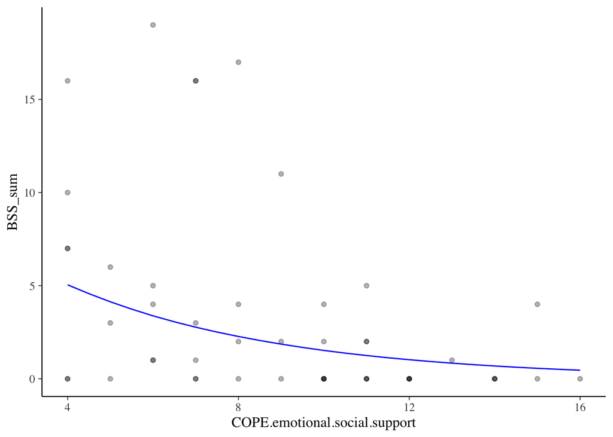

```r
range.COPE.ess <- range(dat$COPE.emotional.social.support)
spread <- seq(range.COPE.ess[1], range.COPE.ess[2], by = .5)
newdata <- data.frame(
  FCESD = mean(dat$FCESD),
  COPE.emotional.social.support = spread)
preds <- posterior_linpred(fit2, newdata=newdata, transform=TRUE)
preds <- apply(preds, 2, median)
preds <- data.frame( COPE.emotional.social.support = spread,
            BSS_sum = preds)
ggplot(dat) +
  aes(y=BSS_sum,x=COPE.emotional.social.support) +
  geom_point(alpha=.3) +
  geom_line(data=preds, col="blue")
```

# 3.0 Suicide attempts and coping

The next step is to look at the relationship between COPE subscales and suicide attempts (as opposed to ideation).

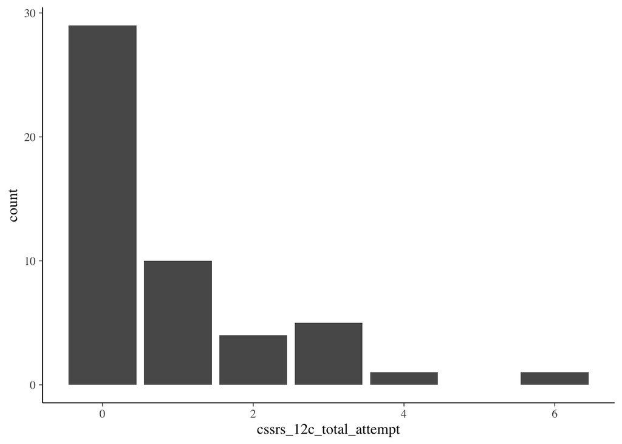

```r
ggplot(dat) +
  aes(x = cssrs_12c_total_attempt) +
  geom_bar()
```

We first run correlations between all the COPE subscales and suicide attempts. In general, the relationships are weaker than those we measured with suicidal ideation. That’s not suprising… The COPE and suicide ideation measures are roughly contemporaneous, whereas distant suicide attempts could have very little relationship with current coping styles.

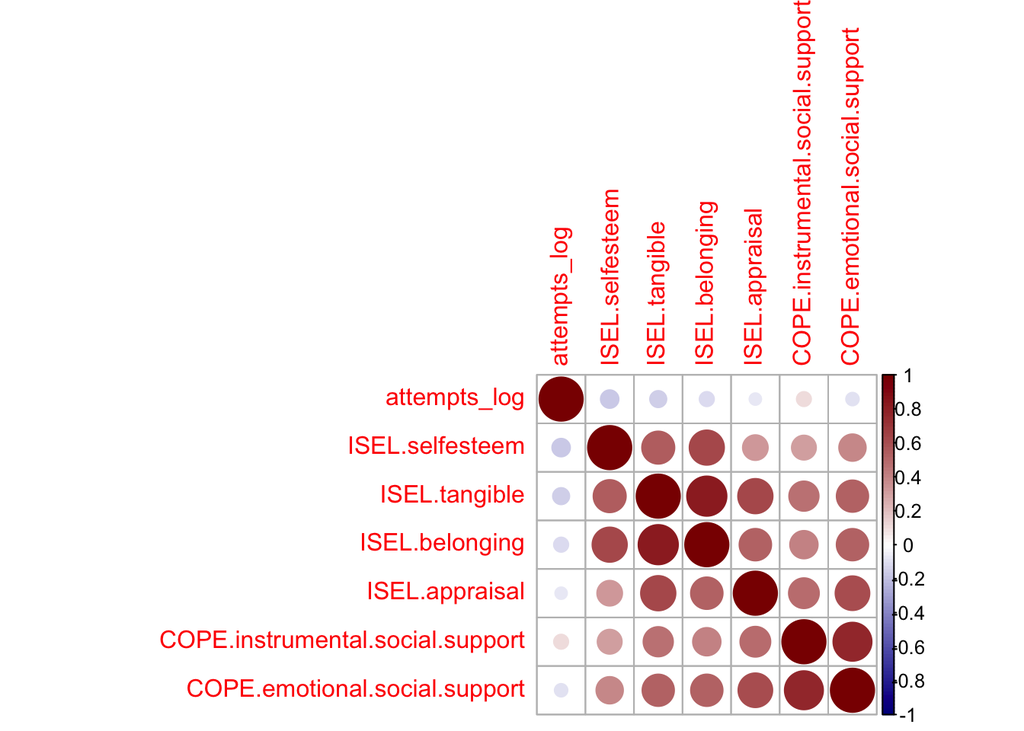

```r
dat$attempts_log <- log(dat$cssrs_12c_total_attempt + 1)
M<-cor(dat[c(social.subscales,"attempts_log")], use = "pairwise.complete.obs")
corrplot(M, method="circle", order="hclust",col=colorRampPalette(c("darkblue", "white", "darkred"))(100))
```

None of the correlations between coping styles and suicide attempts are classically statistically significant (log-transforms don’t make much difference).

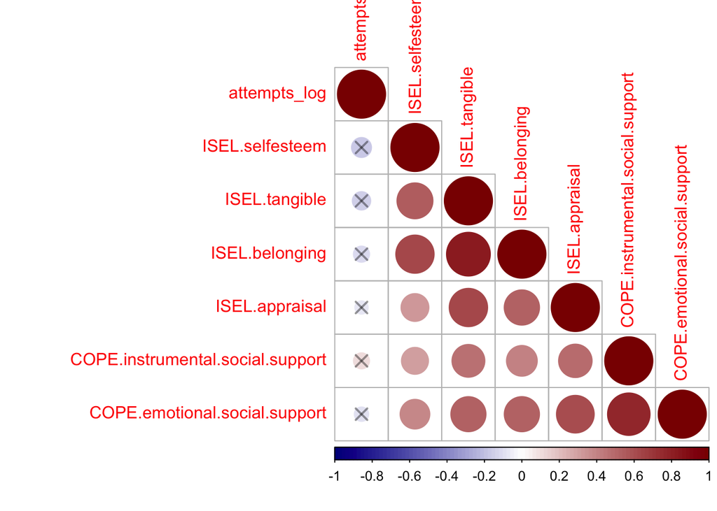

```r
p.mat <- cor.mtest(dat[c(social.subscales,"attempts_log")])
corrplot(M, type="lower", order="hclust",
         col=colorRampPalette(c("darkblue", "white", "darkred"))(100),
         p.mat = p.mat, sig.level = 0.05,
         insig="pch", pch=4, pch.cex=1.5,
         pch.col=rgb(0,0,0,.4))
```

#### Does binarizing change anything?

Maybe we’re reading too far into the number of suicide attempts… Suicide attempts are common in this sample, but in the general population, any history of suicide attempt would make you an outlier. So, we could try treating prior suicide attempts as a binary rather than a continuous variable.

```r
dat$prior_attempt <- dat$cssrs_12c_total_attempt > 0
table(dat$prior_attempt)
```

```
##
## FALSE  TRUE
##    29    21
```

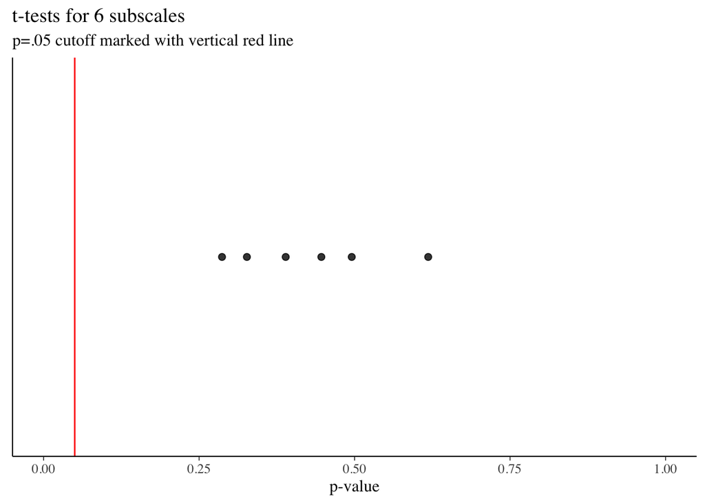

```r
n.tests <- length(social.subscales)
t.tests <- lapply(dat[,as.character(social.subscales[1:n.tests])], function(x) t.test(x ~ dat$prior_attempt, var.equal = TRUE))
# empty data.frame to store p.values
p.values <- data.frame(p.values = 1:n.tests)
# fill data.frame with p.values
for(test in 1:n.tests){
  p.values[test,] <- t.tests[[test]]$p.value
}
ggplot(p.values) +
  aes(x = p.values, y = 0) +
  geom_point(pch=19, cex=2, alpha=.8) +
  geom_vline(xintercept=.05, col="red") +
  xlim(0,1) +
  xlab("p-value") +
  theme(axis.ticks.y=element_blank(),
        axis.title.y=element_blank(),
        axis.text.y=element_blank()) +
  ggtitle(paste("t-tests for",n.tests,"subscales"), subtitle = "p=.05 cutoff marked with vertical red line")
```